# Homework 06

## Question 1: Compare KNN and logistic regression

Use breast-cancer.csv, which contains 569 cases from the [Wisconsin Diagnostic Breast Cancer dataset](https://archive.ics.uci.edu/dataset/17/breast%2Bcancer%2Bwisconsin%2Bdiagnostic). Predict `y` (1 for malignant and 0 for benign) using `mean_radius`, `mean_texture`, and `mean_smoothness`.

Set a random seed and randomly split the observations into 70% training and 30% test data. Use the same split for every model. Standardize the predictors using the training means and standard deviations, and apply the same transformations to the test data.

Fit ordinary logistic regression with an intercept and no penalty, and KNN with Euclidean distance, equal neighbor weights, and

$$k\in\{5,15,25,35,45\}.$$

Using the estimated probabilities for `y = 1` on the test data, plot all six ROC curves in one figure and report their AUC values. Which of the six fitted models do you prefer? Give a brief justification based on your results.

### Solution

I used a seeded random split with 398 training cases and 171 test cases. For each of the three predictors, the mean and sample standard deviation were computed on the training set. The same values were then applied to the test set. The logistic model has an intercept and no penalty; KNN uses Euclidean distance and equal neighbor weights. Its estimated malignancy probability is the fraction of malignant cases among the $k$ nearest training cases.

**Show calculation code**

```python
from pathlib import Path
import numpy as np
import pandas as pd
import matplotlib.pyplot as plt
from IPython.display import display
from sklearn.linear_model import LogisticRegression
from sklearn.neighbors import KNeighborsClassifier
from sklearn.metrics import roc_curve, roc_auc_score

data = pd.read_csv(Path("data") / "breast-cancer.csv")
predictors = ["mean_radius", "mean_texture", "mean_smoothness"]

rng = np.random.default_rng(43206)
train_idx = rng.permutation(len(data))[: int(np.floor(0.70 * len(data)))]
train_mask = np.zeros(len(data), dtype=bool)
train_mask[train_idx] = True
train = data.loc[train_mask]
test = data.loc[~train_mask]

train_means = train[predictors].mean()
train_sds = train[predictors].std(ddof=1)
X_train = ((train[predictors] - train_means) / train_sds).to_numpy()
X_test = ((test[predictors] - train_means) / train_sds).to_numpy()
y_train = train["y"].to_numpy()
y_test = test["y"].to_numpy()

assert len(train) == 398 and len(test) == 171
assert not train_sds.eq(0).any()
assert set(np.unique(y_train)) == {0, 1}
assert set(np.unique(y_test)) == {0, 1}
print(f"Seed: 43206; training cases: {len(train)}; test cases: {len(test)}")
```

```
Seed: 43206; training cases: 398; test cases: 171
```

I compare ROC curves using predicted probabilities for `y = 1`, since ROC and AUC assess ranking over classification thresholds rather than predictions at a single threshold.

**Show calculation code**

```python
logistic = LogisticRegression(
    C=np.inf, fit_intercept=True, solver="lbfgs", tol=1e-10, max_iter=2000
).fit(X_train, y_train)

model_names = ["Logistic regression"] + [f"KNN, k={k}" for k in (5, 15, 25, 35, 45)]
test_probabilities = {"Logistic regression": logistic.predict_proba(X_test)[:, 1]}
for k in (5, 15, 25, 35, 45):
    model = KNeighborsClassifier(
        n_neighbors=k, weights="uniform", metric="euclidean", algorithm="brute"
    ).fit(X_train, y_train)
    test_probabilities[f"KNN, k={k}"] = model.predict_proba(X_test)[:, 1]

q1_auc = pd.DataFrame(
    [(name, roc_auc_score(y_test, test_probabilities[name])) for name in model_names],
    columns=["Model", "Test AUC"],
)
display(q1_auc.round(4))
```

|  | Model | Test AUC |
| --- | --- | --- |
| 0 | Logistic regression | 0.9884 |
| 1 | KNN, k=5 | 0.9656 |
| 2 | KNN, k=15 | 0.9810 |
| 3 | KNN, k=25 | 0.9855 |
| 4 | KNN, k=35 | 0.9884 |
| 5 | KNN, k=45 | 0.9875 |

**Show calculation code**

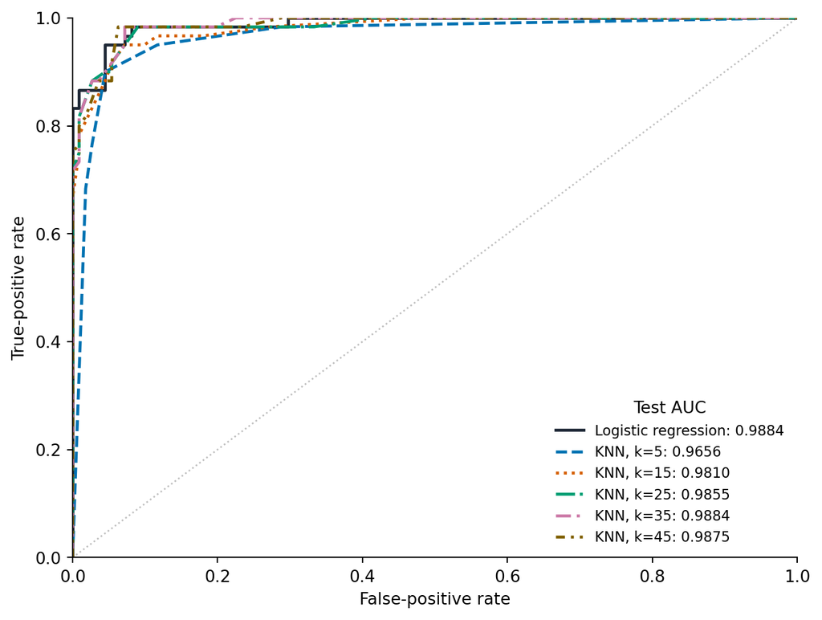

Test ROC curves for logistic regression and five KNN models on the same 171 cases.

```python
fig, ax = plt.subplots(figsize=(7, 5.3))
colors = ["#1f2937", "#0072B2", "#D55E00", "#009E73", "#CC79A7", "#806000"]
styles = ["-", "--", ":", "-.", (0, (5, 2, 1, 2)), (0, (3, 2, 1, 2, 1, 2))]
ax.plot([0, 1], [0, 1], color="0.75", linestyle=":", linewidth=1)
for j, name in enumerate(model_names):
    fpr, tpr, _ = roc_curve(y_test, test_probabilities[name])
    ax.plot(
        fpr, tpr, color=colors[j], linestyle=styles[j], linewidth=1.8,
        label=f"{name}: {q1_auc.loc[j, 'Test AUC']:.4f}",
    )
ax.set(xlim=(0, 1), ylim=(0, 1), xlabel="False-positive rate", ylabel="True-positive rate")
ax.legend(loc="lower right", frameon=False, fontsize=8.5, title="Test AUC")
ax.spines[["top", "right"]].set_visible(False)
fig.tight_layout()
plt.show()
```

I prefer logistic regression on this split. Its test AUC is $0.9884$, effectively tied with 35NN to four decimals and slightly above the other reported KNN values; the fitted logistic rule is also simpler to describe. This small difference on one held-out sample does not establish that logistic regression always performs better. For a deployed model, I would choose the method and $k$ using validation within the training data before using a fresh test set for the final comparison.

## Question 2: Training and test ROC curves

Use the same data, training/test split, and standardization as in Question 1. Fit KNN with Euclidean distance, equal neighbor weights, and

$$k\in\{1,3,5,10,20\}.$$

Use each fitted model to estimate probabilities for both the training and test observations. For training predictions, include each observation itself among its $k$ nearest neighbors.

For each $k$, use a separate panel to show the training and test ROC curves together. Report both AUC values.

Explain the difference between training and test performance and how it changes with $k$. In particular, explain what happens at $k=1$ and why training performance may not reflect performance on new observations.

### Solution

I reused the split and the training-based transformation from Question 1. For each fitted KNN model, I explicitly pass `X_train` to `predict_proba` to include each training observation itself among its neighbors. This convention matters most at $k=1$: every training case predicts its own observed class and therefore has training AUC exactly 1.

**Show calculation code**

```python
q2_k_values = (1, 3, 5, 10, 20)
q2_train_probabilities = {}
q2_test_probabilities = {}
q2_rows = []
for k in q2_k_values:
    model = KNeighborsClassifier(
        n_neighbors=k, weights="uniform", metric="euclidean", algorithm="brute"
    ).fit(X_train, y_train)
    p_train = model.predict_proba(X_train)[:, 1]
    p_test = model.predict_proba(X_test)[:, 1]
    q2_train_probabilities[k] = p_train
    q2_test_probabilities[k] = p_test
    q2_rows.append(
        (k, roc_auc_score(y_train, p_train), roc_auc_score(y_test, p_test))
    )

q2_auc = pd.DataFrame(q2_rows, columns=["k", "Training AUC", "Test AUC"])
q2_auc["Training minus test"] = q2_auc["Training AUC"] - q2_auc["Test AUC"]
assert np.array_equal(q2_train_probabilities[1], y_train)
display(q2_auc.round(4))
```

|  | k | Training AUC | Test AUC | Training minus test |
| --- | --- | --- | --- | --- |
| 0 | 1 | 1.0000 | 0.9268 | 0.0732 |
| 1 | 3 | 0.9875 | 0.9578 | 0.0296 |
| 2 | 5 | 0.9814 | 0.9656 | 0.0158 |
| 3 | 10 | 0.9787 | 0.9722 | 0.0065 |
| 4 | 20 | 0.9756 | 0.9842 | -0.0086 |

**Show calculation code**

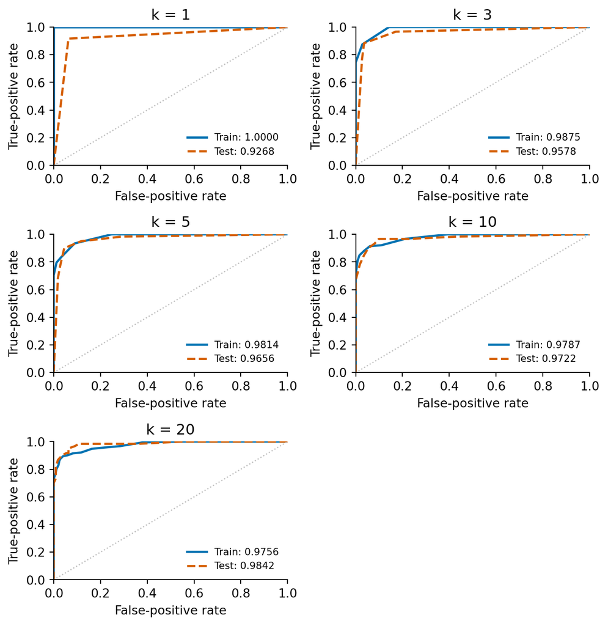

Training and test ROC curves for each neighborhood size. Training predictions include each observation itself.

```python
fig, axes = plt.subplots(3, 2, figsize=(7, 7.2))
for j, k in enumerate(q2_k_values):
    ax = axes.flat[j]
    fpr_train, tpr_train, _ = roc_curve(y_train, q2_train_probabilities[k])
    fpr_test, tpr_test, _ = roc_curve(y_test, q2_test_probabilities[k])
    ax.plot(fpr_train, tpr_train, color="#0072B2", linewidth=1.8,
            label=f"Train: {q2_auc.loc[j, 'Training AUC']:.4f}")
    ax.plot(fpr_test, tpr_test, color="#D55E00", linestyle="--", linewidth=1.8,
            label=f"Test: {q2_auc.loc[j, 'Test AUC']:.4f}")
    ax.plot([0, 1], [0, 1], color="0.75", linestyle=":", linewidth=1)
    ax.set(title=f"k = {k}", xlim=(0, 1), ylim=(0, 1),
           xlabel="False-positive rate", ylabel="True-positive rate")
    ax.legend(loc="lower right", frameon=False, fontsize=8)
    ax.spines[["top", "right"]].set_visible(False)
axes.flat[-1].set_visible(False)
fig.tight_layout()
plt.show()
```

The training AUC is strongly optimistic for the smallest neighborhoods because the same labeled cases determine the rule and are then used for evaluation. At $k=1$, self-inclusion makes the training result perfect by construction, but a new case cannot use its unknown label. Its test AUC is $0.9268$, versus $1.0000$ on training data. As $k$ rises from 1 to 20, the test AUC increases from $0.9268$ to $0.9842$, while the training AUC falls from $1.0000$ to $0.9756$. The training–test gap shrinks and is slightly negative at $k=20$: a particular test sample can rank better than the training sample, so training performance is not always numerically higher. At $k=1$, predicted probabilities are only 0 or 1, giving the test ROC curve just one nontrivial interior point. Training results, especially the perfect 1NN result, do not measure performance on new cases.

## Question 3: Peer evaluation of Homework 5

You will receive two Homework 5 submissions to review. The instructor’s GitHub account, **rqzhu-aide**, will open a **GitHub Issue** in the repository containing your Homework 5 submission. It will contain links to two other students’ repositories, where you can find their submitted homework reports.

Open your repository’s **Issues** tab on GitHub to find the assignment. You may ask AI to explain GitHub Issues or help you locate the assignment.

Choose **one specific mistake or item for improvement** from any question in either report.

1. **Identify the mistake or item for improvement.** State which report and question you selected, and briefly describe what is wrong or could be improved. Examples include incorrect code, a calculation error, a misinterpretation of results, a plot that could communicate the findings more clearly, or anything else you think could be done better.
2. **Explain your assessment.** Quote the relevant text, code, or figure caption exactly. Explain why the selected answer is incorrect or how it could be improved, referring to its reasoning, calculations, code, figures, or interpretation. **Complete this part yourself, without AI assistance.**
3. **Provide a correction.** Write a corrected or improved answer to the selected question, including any calculations, code, or figures needed.

After completing your review, **open a GitHub Issue in the repository containing the report you selected**. Identify the report and question, and include your assessment and a detailed revision plan explaining what the author should change and why. Include a link to your posted GitHub Issue in your Homework 6 answer.

### Solution

#### 1. Item selected

I selected [brisajasso’s Homework 05 report](https://github.com/brisajasso/stat432-fall2026/blob/main/homework/week-05/homework-05.pdf), Question 1, page 2. In the paragraph below Figure 1, the report says:

> “variance falls from 0.037 at $k=1$ toward $\sigma^2/k$ as more responses are averaged.”

This description of the simulated variance needs clarification.

#### 2. My assessment (written without AI assistance)

> The Question 1 statement that variance falls from 0.037 at k=1 toward $\sigma^2/k$ as more responses are averaged is unjustified. I think there needs to be more justifications anad explanations for this.

#### 3. Correction

Across the 200 repeated datasets, both the training covariates and the response noise vary. If $N_k(x_0)$ denotes the indices of the $k$ selected neighbors, then

$$\widehat f_k(x_0)
=\frac{1}{k}\sum_{j\in N_k(x_0)}\{f(\mathbf X_j)+\epsilon_j\}.$$

The noise terms contribute $\sigma^2/k$ conditionally on the training covariates. Because the neighbors’ covariates also change from repetition to repetition, the total variance obeys

$$\operatorname{Var}\{\widehat f_k(x_0)\}
=
\operatorname{Var}_{\mathbf X}\!\left\{\frac{1}{k}\sum_{j\in N_k(x_0)}f(\mathbf X_j)\right\}
+\frac{\sigma^2}{k}.$$

The report’s table illustrates the distinction. At $k=1$, the empirical variance is $0.03718$ and the noise component is $0.01$, leaving about $0.02718$ associated with varying covariates and neighbors. At $k=29$, the corresponding figures are $0.00747$ and $0.01/29\approx0.000345$, leaving about $0.00713$. These differences are approximate because the table contains simulation estimates rounded to five decimals.

A more precise interpretation is that the *observed total variance decreases* as $k$ grows in this experiment, while $\sigma^2/k$ accounts for only its response-noise component. The corrected explanation retains the report’s bias–variance comparison without equating the two quantities.

I posted the assessment and detailed revision plan in [the peer review GitHub issue](https://github.com/brisajasso/stat432-fall2026/issues/2).

### Additional review: stallur10, Homework 05 Question 5

I also reviewed [stallur10’s Homework 05 report](https://github.com/stallur10/stat432-fall2026/blob/main/homework/week-05/homework-05.html). Its plot-formatting skill specifies:

> Default to a 6.5 by 4.5 inch figure, 12-point axis/tick labels, and a 14-point title

Yet its single-panel example uses:

```python
plt.xticks(k_values[::2], fontsize=10)
plt.yticks(fontsize=10)
```

My assessment (written without AI assistance):

> The skill says labels should defaut to 12 pts but the example uses 10 pt x, y-ticks. That doesn’t seem to match the example well.

The example can follow its stated default by setting both tick-label font sizes to 12 while leaving the existing axis labels and title as they are. If the x-axis becomes crowded, showing fewer tick positions or widening the figure would keep the labels readable. Alternatively, the skill could explicitly change its default to 10-point ticks. The skill and example should state and implement the same rule. I posted this assessment and the revision plan in [the second peer review GitHub issue](https://github.com/stallur10/stat432-fall2026/issues/3).